# Assignment-5 report

Ufuk Cem Birbiri

11/28/2021

### 1.Supervised model

#### 1.1 Dataset

First we import some libraries.

```r
library(readr)
library(datasets)
library(dplyr)
library(tidyverse)
library(mlbench)
library(caret)
library(doMC)
library(corrplot)
library(knitr)
set.seed(71)
```

Then load the Glass dataset.

```r
data("Glass")
dim(Glass)
```

```
## [1] 214  10
```

There are 214 samples in the dataset and 10 features. Let’s see the faetures.

```r
kable(head(Glass,5))
```

| RI | Na | Mg | Al | Si | K | Ca | Ba | Fe | Type |
| --- | --- | --- | --- | --- | --- | --- | --- | --- | --- |
| 1.52101 | 13.64 | 4.49 | 1.10 | 71.78 | 0.06 | 8.75 | 0 | 0 | 1 |
| 1.51761 | 13.89 | 3.60 | 1.36 | 72.73 | 0.48 | 7.83 | 0 | 0 | 1 |
| 1.51618 | 13.53 | 3.55 | 1.54 | 72.99 | 0.39 | 7.78 | 0 | 0 | 1 |
| 1.51766 | 13.21 | 3.69 | 1.29 | 72.61 | 0.57 | 8.22 | 0 | 0 | 1 |
| 1.51742 | 13.27 | 3.62 | 1.24 | 73.08 | 0.55 | 8.07 | 0 | 0 | 1 |

It would be better to shuffle the dataset because the “Type” feature is ordered.

```r
shuffle_index <- sample(1:nrow(Glass))
Glass <- Glass[shuffle_index, ]
kable(head(Glass,5))
```

|  | RI | Na | Mg | Al | Si | K | Ca | Ba | Fe | Type |
| --- | --- | --- | --- | --- | --- | --- | --- | --- | --- | --- |
| 59 | 1.51754 | 13.48 | 3.74 | 1.17 | 72.99 | 0.59 | 8.03 | 0.00 | 0.00 | 1 |
| 28 | 1.51721 | 12.87 | 3.48 | 1.33 | 73.04 | 0.56 | 8.43 | 0.00 | 0.00 | 1 |
| 207 | 1.51645 | 14.94 | 0.00 | 1.87 | 73.11 | 0.00 | 8.67 | 1.38 | 0.00 | 7 |
| 48 | 1.52667 | 13.99 | 3.70 | 0.71 | 71.57 | 0.02 | 9.82 | 0.00 | 0.10 | 1 |
| 129 | 1.52068 | 13.55 | 2.09 | 1.67 | 72.18 | 0.53 | 9.57 | 0.27 | 0.17 | 2 |

The “Type” would be our class label. Let’s see them:

```r
unique(Glass$Type)
```

```
## [1] 1 7 2 6 3 5
## Levels: 1 2 3 5 6 7
```

Distribution of class variable:

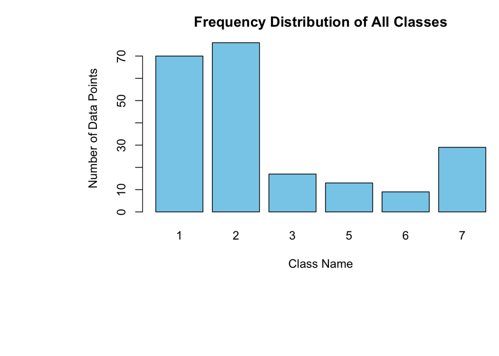

List the types of features:

```r
sapply(Glass, class)
```

```
##        RI        Na        Mg        Al        Si         K        Ca        Ba
## "numeric" "numeric" "numeric" "numeric" "numeric" "numeric" "numeric" "numeric"
##        Fe      Type
## "numeric"  "factor"
```

Show the mean of each feature:

```r
sapply(Glass[,1:9], mean)
```

```
##          RI          Na          Mg          Al          Si           K
##  1.51836542 13.40785047  2.68453271  1.44490654 72.65093458  0.49705607
##          Ca          Ba          Fe
##  8.95696262  0.17504673  0.05700935
```

Show the standard deviation of each feature:

```r
sapply(Glass[,1:9], sd)
```

```
##          RI          Na          Mg          Al          Si           K
## 0.003036864 0.816603556 1.442407845 0.499269646 0.774545795 0.652191846
##          Ca          Ba          Fe
## 1.423153487 0.497219261 0.097438701
```

Now let’s visualize the correlation matrix of each feature:

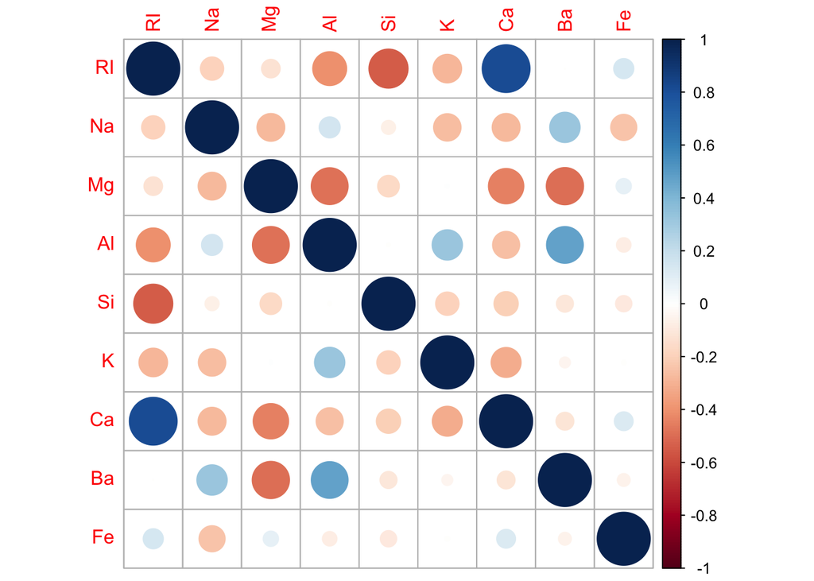

Positive correlations are displayed in blue and negative correlations in red color. Color intensity and the size of the circle are proportional to the correlation coefficients. **We can easily see that Ca is highly correlated with RI**. So we can remove one of those from our analysis.

```r
x <- Glass[,2:9]
y <- Glass[,10]
```

Let’s see our new datasets:

```r
kable(head(x,3))
```

|  | Na | Mg | Al | Si | K | Ca | Ba | Fe |
| --- | --- | --- | --- | --- | --- | --- | --- | --- |
| 59 | 13.48 | 3.74 | 1.17 | 72.99 | 0.59 | 8.03 | 0.00 | 0 |
| 28 | 12.87 | 3.48 | 1.33 | 73.04 | 0.56 | 8.43 | 0.00 | 0 |
| 207 | 14.94 | 0.00 | 1.87 | 73.11 | 0.00 | 8.67 | 1.38 | 0 |

#### 1.2 SVM model

Run algorithms using 10-fold cross validation:

```r
control <- trainControl(method="repeatedcv", number=10, repeats=3)
```

```r
grid <- expand.grid(.sigma=c(0.01,0.05,0.1,0.5,1,10), .C=c(1))
fit.svm <- train(Type~., data=Glass, method="svmRadial",
                 metric="Accuracy", tuneGrid=grid,
                 trControl=control)
results <- list(SVM=fit.svm)
results
```

```
## $SVM
## Support Vector Machines with Radial Basis Function Kernel
##
## 214 samples
##   9 predictor
##   6 classes: '1', '2', '3', '5', '6', '7'
##
## No pre-processing
## Resampling: Cross-Validated (10 fold, repeated 3 times)
## Summary of sample sizes: 191, 191, 193, 193, 193, 191, ...
## Resampling results across tuning parameters:
##
##   sigma  Accuracy   Kappa
##    0.01  0.5572804  0.3468270
##    0.05  0.6656878  0.5206861
##    0.10  0.7079895  0.5850082
##    0.50  0.6671867  0.5176769
##    1.00  0.6525064  0.4890757
##   10.00  0.4965075  0.2260276
##
## Tuning parameter 'C' was held constant at a value of 1
## Accuracy was used to select the optimal model using the largest value.
## The final values used for the model were sigma = 0.1 and C = 1.
```

Now let’s see the confusion matrix:

```r
confusionMatrix(fit.svm)
```

```
## Cross-Validated (10 fold, repeated 3 times) Confusion Matrix
##
## (entries are percentual average cell counts across resamples)
##
##           Reference
## Prediction    1    2    3    5    6    7
##          1 26.8  8.1  4.7  0.0  0.5  0.5
##          2  5.9 26.3  3.3  1.4  1.4  1.6
##          3  0.0  0.0  0.0  0.0  0.0  0.0
##          5  0.0  0.5  0.0  4.2  0.5  0.0
##          6  0.0  0.6  0.0  0.0  1.9  0.0
##          7  0.0  0.0  0.0  0.5  0.0 11.5
##
##  Accuracy (average) : 0.7072
```

Since this is a multi-class classification problem, it is a bit hard to detect FP,TP,FN,TN.

### 2.Unsupervised models: Dimension Reduction

#### 2.1 t-SNE

We use iris dataset for dimension reduction. Loading the iris dataset into a object called IR.

```r
IR<-data("iris")
IR <- iris
```

Split IR into two objects: 1) containing measurements 2) containing species type:

```r
IR_data <- IR[ ,1:4]
IR_species <- IR[ ,5]
```

Load the t-SNE library

```r
library(Rtsne)
```

Run the t-SNE algorithm and store the results into an object called tsne_results:

```r
tsne_results <- Rtsne(IR_data, perplexity=30, check_duplicates = FALSE) # You can change the value of perplexity and see how the plot changes
```

Generate the t_SNE plot

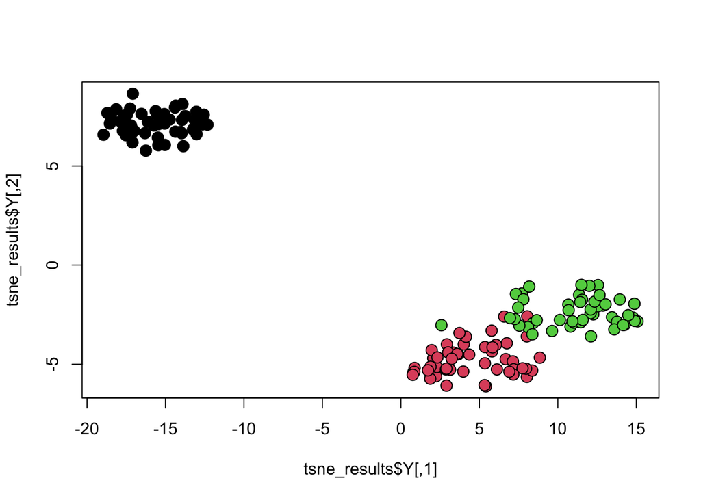

```r
plot(tsne_results$Y, col = "black", bg= IR_species, pch = 21, cex = 1.5)
```

#### 2.2 PCA

To plot PCA, first we need to import following library:

```r
library(ggfortify)
```

Now, visualize the PCA:

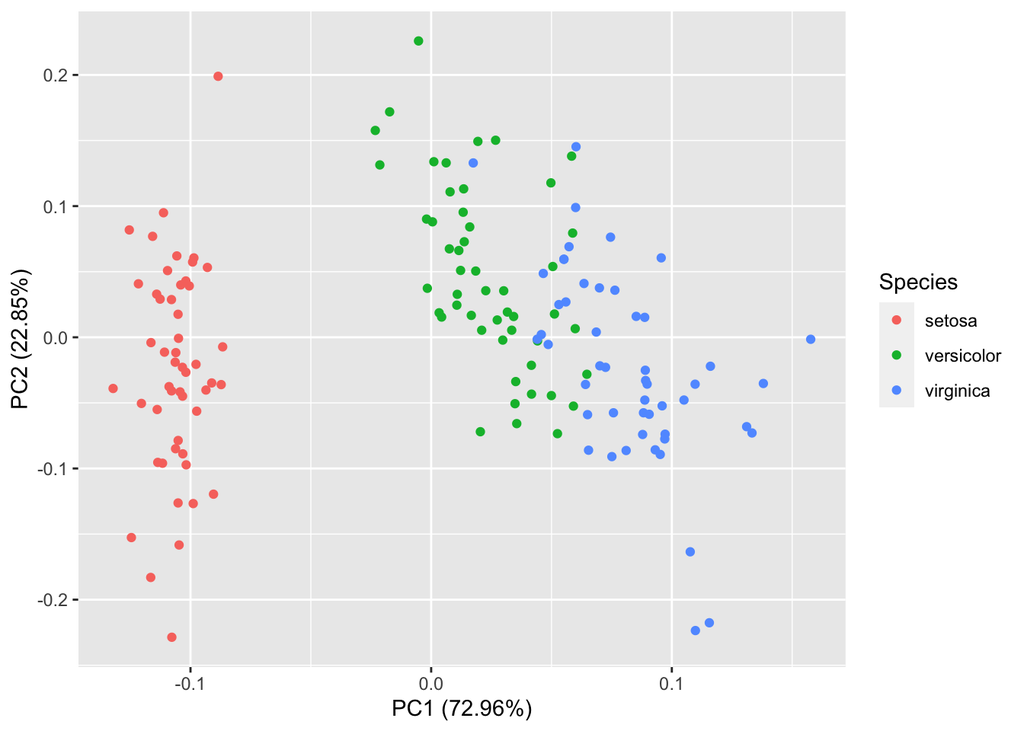

```r
pca_res <- prcomp(IR_data, scale. = TRUE)
autoplot(pca_res, data = iris, colour = 'Species', label = FALSE, label.size = 3)
```

Since the iris dataset is not very complex and does not have many dimensions, it seems that both PCA and t-SNE works well.